# Big data with R

Steve Elston  
March 29, 2016

### Big data packages for R

Two viable alterntives:

- **[R Hadoop ecosystem:](https://github.com/RevolutionAnalytics/RHadoop/wiki)** rmr2, rhdfs, rhbase, plyrmr, ravro
- **[Tessera ecosystem:](http://tessera.io/)** datadr, trelliscope, Rhipe
- Apply familar R funcitons with both alternatives

### Tessera overview

Tessera encompases three packages:

- **[datadr:](http://tessera.io/docs-datadr/)** abstracts most divide and recombine operations on map-reduce back-end
- **[trelliscope:](http://tessera.io/docs-trelliscope/)** facilitates visualization of large complex datasets
- **[RHIPE](http://tessera.io/docs-RHIPE/)** provides a backend interface to Hadoop

### Tessera stack

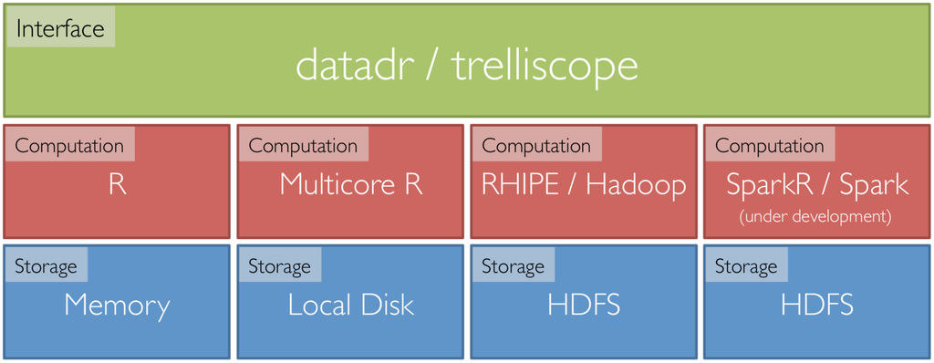

### Distributed R object

Distributing data by key-value pairs

- **Distributed data object (ddo)**: values can be any R object, list, etc.
- **Distributed data frame (ddf)** is a ddo containing data frames as the values

### Introduction to divide and recombine

- Meaningful, persistent divisions of the data
- Analytic or visual methods applied independently to each subset in embarrassingly parallel fashion
- Results are recombined to yield a statistically valid D&R result or visualization

### Introduction to divide and recombine

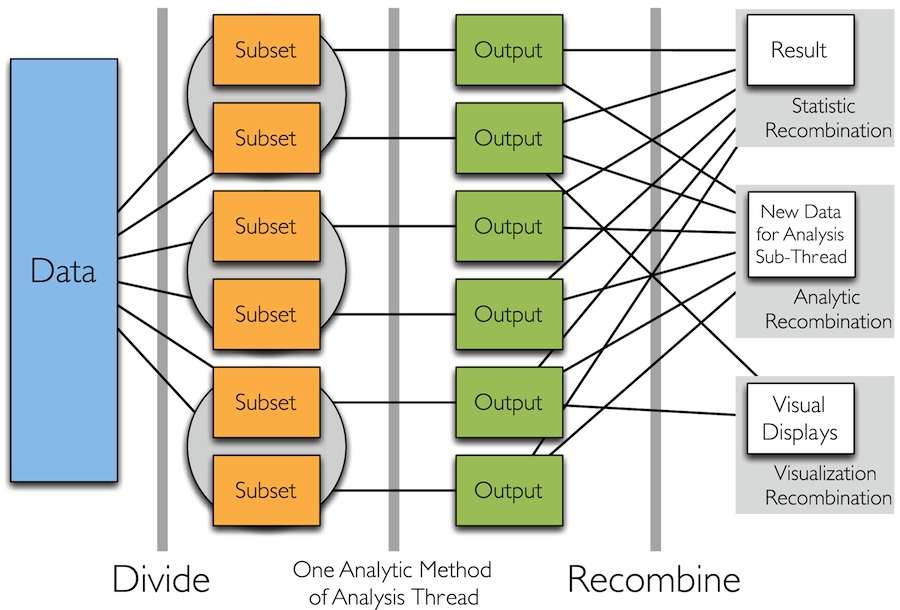

### Installing datadr

Let's give it a try!

```r
## Install the packages and the housing data set from CRAN.
#install.packages("devtools")
#library(devtools)
#options(repos = c(tessera = "http://packages.tessera.io",
#                  getOption("repos")))
install.packages(c("datadr", "trelliscope", "housingData"))
```

### Introduction to division

- “Big data” is typically big because it is made up of collections of many subsets, sensors, locations, time periods, etc.
- Break the data up based on data structure and apply visual or analytical methods
- We call this conditioning variable division
- In practice this approach is common and not new
- Another option is random replicate division

### Create a distributed data frame with datadr

```r
library(datadr)
library(housingData)
housingDdf <- ddf(housing)
```

### Examine the distributed data frame

```r
housingDdf
```

```
Distributed data frame backed by 'kvMemory' connection

 attribute      | value
----------------+-----------------------------------------------------------
 names          | fips(fac), county(fac), state(fac), time(Dat), and 3 more
 nrow           | 224369
 size (stored)  | 10.58 MB
 size (object)  | 10.58 MB
 # subsets      | 1

* Other attributes: getKeys()
* Missing attributes: splitSizeDistn, splitRowDistn, summary
```

### But there are no keys

```r
names(housingDdf)
```

```
[1] "fips"             "county"           "state"
[4] "time"             "nSold"            "medListPriceSqft"
[7] "medSoldPriceSqft"
```

```r
getKeys(housingDdf)
```

```
[[1]]
[1] ""
```

### Dividing a dataset with datadr

```r
byCounty <- divide(housingDdf,
                   by = c("county", "state"),
                   update = TRUE)
```

How many keys are there?

```r
keys <- getKeys(byCounty)
length(keys)
```

```
[1] 2883
```

### What are the keys?

Example of keys:

```r
firstKey <- keys[[1]]
firstKey
```

```
[1] "county=Abbeville County|state=SC"
```

Look at the names:

```r
names(byCounty)
```

```
[1] "fips"             "time"             "nSold"
[4] "medListPriceSqft" "medSoldPriceSqft"
```

### Look at one key-value pair

```r
byCounty[firstKey]
```

```
[[1]]
$key
[1] "county=Abbeville County|state=SC"

$value
   fips       time nSold medListPriceSqft medSoldPriceSqft
1 45001 2008-10-01    NA         73.06226               NA
2 45001 2008-11-01    NA         70.71429               NA
3 45001 2008-12-01    NA         70.71429               NA
4 45001 2009-01-01    NA         73.43750               NA
5 45001 2009-02-01    NA         78.69565               NA
...
```

### Summary of the result

```r
summary(byCounty)
```

```
        fips                 time                nSold
 -------------------  ------------------  -------------------
       levels : 2883  missing :        0   missing :   164370
      missing : 0         min : 08-10-01       min :       11
 > freqTable head <       max : 14-03-01       max :    35619
 26077 : 140                                  mean : 274.6582
 51069 : 140                               std dev : 732.2429
 08019 : 139                              skewness :   10.338
 13311 : 139                              kurtosis : 222.8995
 -------------------  ------------------  -------------------
   medListPriceSqft     medSoldPriceSqft
 --------------------  -------------------
  missing :     48399   missing :   162770
      min : 0.5482456       min : 17.40891
      max :  1544.944       max : 1249.494
     mean :  96.72912      mean : 105.5659
  std dev :  56.12035   std dev : 69.40658
 skewness :  6.816523  skewness : 5.610013
 kurtosis :  94.06555  kurtosis : 60.48337
 --------------------  -------------------
```

### Your turn

Try the following:

- Make sure you have opened **port 8100** (uses Shiny)
- Load the datadr and housingData packages
- Create a ddf from housing data frame
- Divide your ddf by some interesting keys
- Examine the keys

### A possible solution

```r
library(datadr)
library(housingData)
myDdf <- ddf(housing)
myDdf <- divide(myDdf,
                   by = "time",
                   update = TRUE)
newKeys <- getKeys(myDdf)
length(newKeys)
```

```
[1] 66
```

```r
newKeys[[1]]
```

```
[1] "time=2008-10-01"
```

### Adding a transform to a ddf

Create and test a transform function

```r
totalSold <- function(x) {
  sum(x$nSold, na.rm=TRUE)
}
totalSold(byCounty[[20]]$value)
```

```
[1] 14173
```

### Apply transform to a ddf

Create new ddf with transform and look at a k-v pair

```r
byCountySold <- addTransform(byCounty, totalSold)
byCountySold[[20]]
```

```
$key
[1] "county=Aiken County|state=SC"

$value
[1] 14173
```

### Join creates a ddo

Join on common keys

```r
byCountyNSold <- drJoin(housing = byCounty, totalSold = byCountySold)
getKeys(byCountyNSold)[[1]]
```

```
[1] "county=Abbeville County|state=SC"
```

### Examine the joined ddo

```r
byCountyNSold[[20]]$key
```

```
[1] "county=Aiken County|state=SC"
```

```r
byCountyNSold[[20]]$value$totalSold
```

```
[1] 14173
```

```r
byCountyNSold[[20]]$value$housing
```

```
     fips       time nSold medListPriceSqft medSoldPriceSqft
1   45003 2008-10-01   211        100.50287          85.3414
2   45003 2008-11-01   152        100.48913               NA
3   45003 2008-11-01    NA               NA          84.3824
4   45003 2008-12-01   197               NA               NA
5   45003 2008-12-01    NA        101.22699          84.2980
6   45003 2009-01-01   228        101.90736          82.9887
7   45003 2009-02-01   171        101.55889               NA
8   45003 2009-02-01    NA               NA          78.2722
9   45003 2009-03-01   223               NA               NA
10  45003 2009-03-01    NA         99.97500          80.1041
11  45003 2009-04-01   232         99.92593          85.1870
12  45003 2009-05-01   211         99.65517               NA
13  45003 2009-05-01    NA               NA          85.3452
14  45003 2009-06-01   263               NA               NA
```

[output cut: 93 more lines]

### Your turn!

Apply a transform to your ddf

- Create a function to compute a summary statistic
- Test your function on a subset of your ddf
- Apply your function as a transform to your ddf
- Examine the results

### A possible solution, part 1

Create and test the function

```r
priceDiff <- function(x){
  mean(x$medSoldPriceSqft - x$medListPriceSqft, na.rm = TRUE)
  }
priceDiff(myDdf[[1]]$value)
```

```
[1] -9.045783
```

### A possible solution, part 2

Apply the transformation

```r
diffByMonth <- addTransform(myDdf, priceDiff)
class(diffByMonth)
```

```
[1] "transformed" "ddo"         "kvMemory"
```

```r
diffByMonth[[1]]
```

```
$key
[1] "time=2008-10-01"

$value
[1] -9.045783
```

### Review

Handle large data sets by dividing into key-value pairs

- Keys index the data chunks
- Data chunks are the values
- k-v pairs can be ddo or ddf

Transform data with addTransform

- Most any R function
- Uses lazy evaluation

### Some datadr functions for divisions

- **drLapply():** apply a function to each subset of a ddo/ddf and obtain a new ddo/ddf
- **drSample():** take a random sample of subsets of a ddo/ddf
- **drFilter():** filter out subsets of a ddo/ddf that meet a specified criteria
- **drSubset():** return a subset data frame of a ddf
- **drRead.table()** and friends
- **mrExec():** run a traditional MapReduce job on a ddo/ddf

### Division independent datadr methods

- **drQuantile():** estimate all-data quantiles, optionally by a grouping variable
- **drAggregate():** all-data tabulation
- **drHexbin():** all-data hexagonal binning aggregation
- **summary()** method computes numerically stable moments, other summary stats

### Analytic recombination

What is the class of the object created with the transform?

```r
class(byCountySold)
```

```
[1] "transformed" "ddo"         "kvMemory"
```

### Analytic recombination

The *combine* parameter of the *recombine* function controls the form of the result

- **combine=combRbind:** combines all transformed key-value pairs into a local data frame - frequently used
- **combine=combCollect:** transformed key-value pairs are collected into a local list in your R session
- **combine=combDdo:** results are combined into a new ddo object
- **combMeanCoef:** computes the mean of model coefficients
- Others can be written for more sophisticated goals, such as, combining models, etc.

### Analytic recombination example

Apply recombine to the ddo

```r
nSold <- recombine(byCountySold,
                   combine=combRbind)
```

The result is a simple local dataframe

```r
class(nSold)
```

```
[1] "data.frame"
```

```r
names(nSold)
```

```
[1] "county" "state"  "val"
```

### Your turn!

- Start with the result of the last exercice
- Examine the classs
- Recombine the results
- Examine the properties of the recombined results

### A posible solution, Part 1

Class of transformation result

```r
class(diffByMonth)
```

```
[1] "transformed" "ddo"         "kvMemory"
```

Recombine the results

```r
diffByMonthdf <- recombine(diffByMonth,
                   combine=combRbind)
```

### A posible solution, Part 2

The class of the recombined result

```r
class(diffByMonthdf)
```

```
[1] "data.frame"
```

The columns of the local data frame

```r
names(diffByMonthdf)
```

```
[1] "time" "val"
```

### Visualization of large complex data sets

Use Trelliscope for visual recombination

- Trelliscope is specifically designed to visualize large complex datasets
- Trelliscope visualizes k-v pairs
- Displays are conditioned by keys
- Trelliscope stores its displays in a “Visualization Database” (VDB), a collection of files on your disk containing metadata about the displays

### Setup for trelliscope

To create and view displays, establish a connection to the VDB

```r
library(trelliscope)
# establish a connection to a VDB located in a directory "housing_vdb"
conn <- vdbConn("housing_vdb", autoYes = TRUE)
conn
```

```
vdb connection object: "strata"; path=C:\Users\Steve\Dropbox\Oreilly\Big Data with R\Strata 2016\housing_vdb
```

- If initialized, it simply makes the connection

### Creating a trelliscope display

A Trelliscope display is created with the `makeDisplay()` function with minimum specification of:

- data: a ddo or ddf input data set
- name: the name of the display
- panelFn: a function that operates on the value of each key-value pair and produces a plot

### Recall our data set

```r
class(byCountyNSold)
```

```
[1] "ddo"      "kvMemory"
```

```r
byCountyNSold[[20]]
```

```
$key
[1] "county=Aiken County|state=SC"

$value
$housing
     fips       time nSold medListPriceSqft medSoldPriceSqft
1   45003 2008-10-01   211        100.50287          85.3414
2   45003 2008-11-01   152        100.48913               NA
3   45003 2008-11-01    NA               NA          84.3824
4   45003 2008-12-01   197               NA               NA
5   45003 2008-12-01    NA        101.22699          84.2980
6   45003 2009-01-01   228        101.90736          82.9887
7   45003 2009-02-01   171        101.55889               NA
8   45003 2009-02-01    NA               NA          78.2722
9   45003 2009-03-01   223               NA               NA
```

[output cut: 101 more lines]

### Define a panel function

Use ggplot2 to create a panel function

```r
saleSoldPannel <- function(xx){
  yy <- xx$housing
  ggplot(yy) +
    geom_point(aes(time, medListPriceSqft)) +
    geom_point(aes(time, medSoldPriceSqft), color = "red", shape = 17)
}
```

### Test the panel function

Use ggplot2 to create a panel function

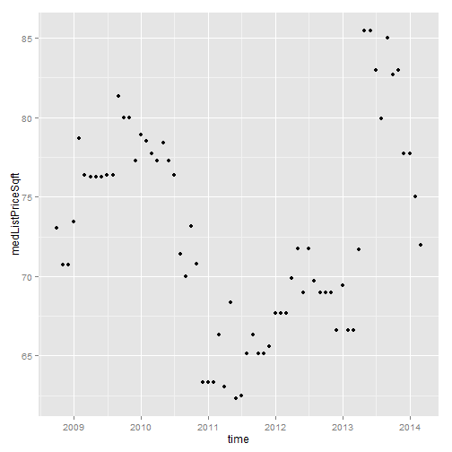

```r
saleSoldPannel(byCountyNSold[[1]]$value)
```

### Make the trelliscope display

```r
makeDisplay(byCountyNSold,
            name = "Strata",
            desc = "List and sold price over time",
            panelFn = saleSoldPannel,
            width = 400, height = 400
)
```

### How to sort a massive number of charts?

“There seems no escape from asking the computer to sort out the displays to be displayed… To do this, the computer must judge the relative different displays, the relative importance of showing them. This means calculating some “diagnostic quantities.” … It seems natural to call such computer guiding diagnostics “cognostics”. We must learn to choose them, calculate them, and use them. Else we drown in a sea of many different displays.” John W. Tukey

### Cognositics with Trelliscope

Cognostic function supplies guideance for visualization

- Cognostic function takes a subset of the data as input and returns a named list of cognostics
- **cog()** function can supply additional attributes like descriptions to help the viewer
- **cogMean** provides cognostic based on mean
- **cogRange** provides cognostic based on range
- **cogHref** creates href cognostic

### Create a cognostic function

```r
zillowCog <- function(x) {
  # return a list of cognostics
  list(
    meanList = cogMean(x$housing$medListPriceSqft),
    meanSold = cogMean(x$housing$medSoldPriceSqft),
    totalSold = cog(x$totalSold, desc = "Total sold")
  )
}
```

### Make the trelliscope display with cognostic

```r
makeDisplay(byCountyNSold,
             name = "Strata cognostics",
             desc = "List and sold price over time",
             panelFn = saleSoldPannel,
             cogFn = zillowCog,
             width = 400, height = 400
 )
```

### Your turn!

Extend and test the cognostic function

- Create, test and apply a new transform (optional)
- Join the resulting statistic to the ddo
- Add the statistic to the cognostic function

**Or**, use one of the cognositc built in functions

### A possible solution, part 1

```r
priceDiff <- function(x){
  y <- x$housing
  mean(y$medSoldPriceSqft - y$medListPriceSqft, na.rm = TRUE)
  }
meanDiff <- addTransform(byCountyNSold, priceDiff)
byCountyDiff <- drJoin(housing = byCounty, totalSold = byCountySold,
                       meanDiff = meanDiff)
```

### A possible solution, part 2

```r
zillowCog2 <- function(x) {
  # return a list of cognostics
  list(
    meanList = cogMean(x$housing$medListPriceSqft),
    meanSold = cogMean(x$housing$medSoldPriceSqft),
    totalSold = cog(x$totalSold, desc = "Total sold"),
    meanDiff = cog(x$meanDiff, desc = "Mean sold-list price difference")
  )
}
```

### A possible solution, part 3

```r
makeDisplay(byCountyDiff,
             name = "Strata cognostics 2",
             desc = "List and sold price over time 2",
             panelFn = saleSoldPannel,
             cogFn = zillowCog2,
             width = 400, height = 400
 )
```

### Review

Divide and recombine for large complex data sets

- Division gives manageable sized data chunks
- Division by keys into key-value pairs
- Recombination can be analytic or visualization
- Trelliscope enables large scale exploration of data
- Cognostics used for computer guided visualization

### Scaling up

Medium data sets can use multi-core and local disk connection

```r
require(parallel)
options(defaultLocalDiskControl = localDiskControl(makeCluster(2)))
strataDiskConn <- localDiskConn(file.path(tempdir(), "strataKV"), autoYes = TRUE)
strataDiskConn
```

```
localDiskConn connection
  loc=C:\Users\Steve\AppData\Local\Temp\Rtmp4O9MB5\strataKV; nBins=0
```

### Adding data to local disk connection

```r
len <- dim(housing)[1]
indx1 <- as.integer(len/2)
indx2 <- indx1 + 1
housingList <- kvPairs(
    list('key1', housing[1:indx1, ]),
    list('key2', housing[indx2:len, ])
  )
addData(strataDiskConn, housingList, overwrite = TRUE)
list.files(strataDiskConn$loc)
```

```
[1] "_meta"
[2] "07abaecdababc84098369b43ae953523.Rdata"
[3] "b1f1dba2f126bc3208b6b84121503757.Rdata"
```

### Create a ddf on disk

```r
housingDdfDisk <- ddf(strataDiskConn, update = TRUE)
housingDdfDisk
```

```
Distributed data frame backed by 'kvLocalDisk' connection

 attribute      | value
----------------+-----------------------------------------------------------
 names          | fips(fac), county(fac), state(fac), time(Dat), and 3 more
 nrow           | 224369
 size (stored)  | 1.98 MB
 size (object)  | 10.88 MB
 # subsets      | 2

* Other attributes: getKeys(), splitSizeDistn(), splitRowDistn(), summary()
```

### Create a new local disk connection

```r
byCountyDiskConn <- localDiskConn(file.path(tempdir(), "byCounty"), autoYes = TRUE)
byCountyDiskConn
```

```
localDiskConn connection
  loc=C:\Users\Steve\AppData\Local\Temp\Rtmp4O9MB5\byCounty; nBins=0
```

### Divide the on-disk ddf

```r
byCountyDisk <- divide(housingDdfDisk,
                   by = c("county", "state"),
                   output = byCountyDiskConn,
                   update = TRUE, overwrite = TRUE)
byCountyDisk
```

```
Distributed data frame backed by 'kvLocalDisk' connection

 attribute      | value
----------------+-----------------------------------------------------------
 names          | fips(cha), time(Dat), nSold(num), and 2 more
 nrow           | 224369
 size (stored)  | 3.13 MB
 size (object)  | 15.21 MB
 # subsets      | 2883

* Other attributes: getKeys(), splitSizeDistn(), splitRowDistn(), summary()
* Conditioning variables: county, state
```

### Try it with Hadoop

Install instructions available for AWS and Azure

- **[For EMR](https://github.com/tesseradata/install-emr)**
- **[For HDInsight](https://github.com/tesseradata/install-hdinsight)**

### Your turn!

Perhaps as homework try the following:

- Create an on-disk ddo
- Try dividing by keys
- Apply a transform or visualize with Trelliscope

### Summary

- Divide into meaningful, persistent divisions of the data
- Analytic or visual methods applied independently to each subset in embarrassingly parallel fashion
- Results are recombined to yield a statistically valid D&R result or visualization
- Scale with multi-core and disk connection or HDFS connection on Hadoop cluster